# Shakespeare Cogsci Analysis

Desmond Ong

January 31, 2016

### Experiment 1: Free-response generation of actions, given emotions.

N=100. Ps responded to the prompt: “Bob ____ because he was feeling Happy/Calm/Sad/Anger/Surprised” Each P sees all 5 emotions, gives 5 responses to each emotion.

Following this, they see all the responses they gave, and gave counterfactual judgments.

“Earlier you said: ’Bob smiled because he was feeling happy. If Bob was not happy, would he still have smiled?” – 7 point Likert from Very Unlikely to Very Likely.

Thus in the first part, they generated samples from Actions|Emotions (i.e., sampling from P(A|E)). In the second part, they gave P(Action | NOT Emotion), (i.e., P(A|notE)).

#### P(A|E): “Bob ____ because he was feeling [Emotion]”

Here are the top 5 responses for each emotion (+ word counts).

| Happy | Calm | Sad | Anger | Surprised |
| --- | --- | --- | --- | --- |
| smiled: 73 | relaxed: 52 | cried: 97 | hit X: 69 (e.g. “punched the wall”) | jumped: 65 |
| laughed: 52 | slept: 46 | frowned: 17 | yelled: 56 | laughed: 41 |
| jumped: 42 | sat down: 34 | slept: 14 | screamed: 27 | screamed: 30 |
| danced: 23 | smiled: 26 | killed himself: 13 | cried: 16 | yelled: 26 |
| cried: 21 | sighed: 10 | yelled: 13 | cursed: 14 | smiled: 23 |

#### P(A | not E)

Here is the distribution of P(A | not E) for the actions they provided.

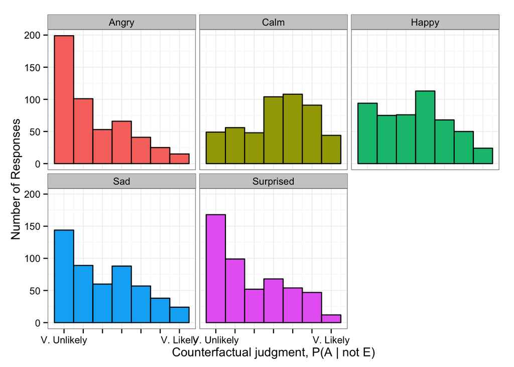

```
## [1] 3.08
```

```
## [1] 1.921
```

```
## [1] 3.328
```

```
## [1] 1.847
```

```
##
##  Welch Two Sample t-test
##
## data:  subsetModal$counterfactual and subsetNotModal$counterfactual
## t = -3.135, df = 1803, p-value = 0.001744
## alternative hypothesis: true difference in means is not equal to 0
## 95 percent confidence interval:
##  -0.40232 -0.09268
## sample estimates:
## mean of x mean of y
##     3.080     3.328
```

#### P(A | not E) vs. P(A|E)

Here, I’ve plotted the counterfactual judgment P(A | not E) on the y axis, against the frequency of that action being nominated, i.e. P(A | E) summarized across participants. There is a significant negative relationship. That is, as the event gets more and more frequently cited (e.g. “cried”), it becomes more and more diagnostic of that emotion (i.e., more unlikely to cry given not sad).

```
## Linear mixed model fit by REML ['lmerMod']
## Formula: counterfactual ~ frequency + (1 | workerid) + (1 | emotion)
##    Data: d1aLong
##
## REML criterion at convergence: 9401
##
## Random effects:
##  Groups   Name        Variance Std.Dev.
##  workerid (Intercept) 0.909    0.953
##  emotion  (Intercept) 0.392    0.626
##  Residual             2.257    1.502
## Number of obs: 2500, groups: workerid, 100; emotion, 5
##
## Fixed effects:
##             Estimate Std. Error t value
## (Intercept)  3.40528    0.29829   11.42
## frequency   -0.00829    0.00116   -7.15
##
## Correlation of Fixed Effects:
##           (Intr)
## frequency -0.078
```

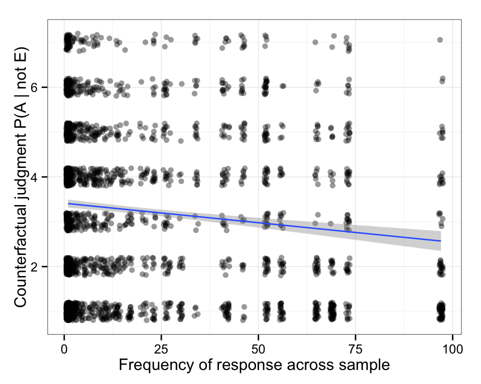

### Study 1b

#### P(x|A): “Bob [Action] because __________”

Below I’ve plotted the frequency of emotion and non-emotion explanations for each action.

```
##  Cohen's Kappa for 2 Raters (Weights: unweighted)
##
##  Subjects = 1500
##    Raters = 2
##     Kappa = 0.935
##
##         z = 67.4
##   p-value = 0
```

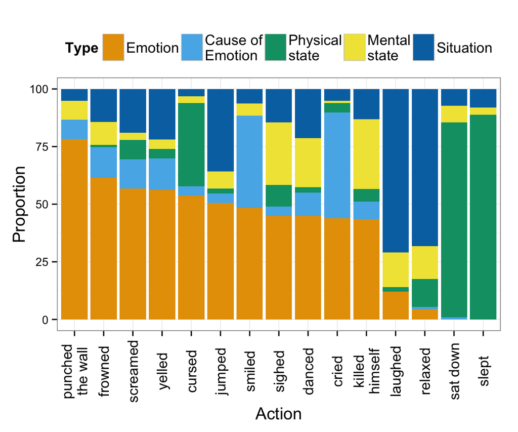

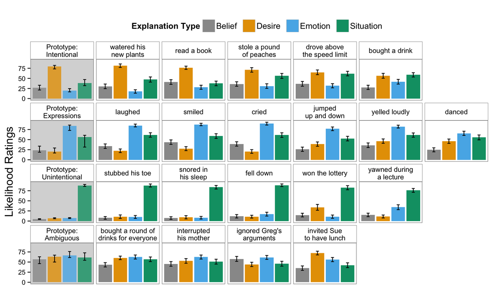

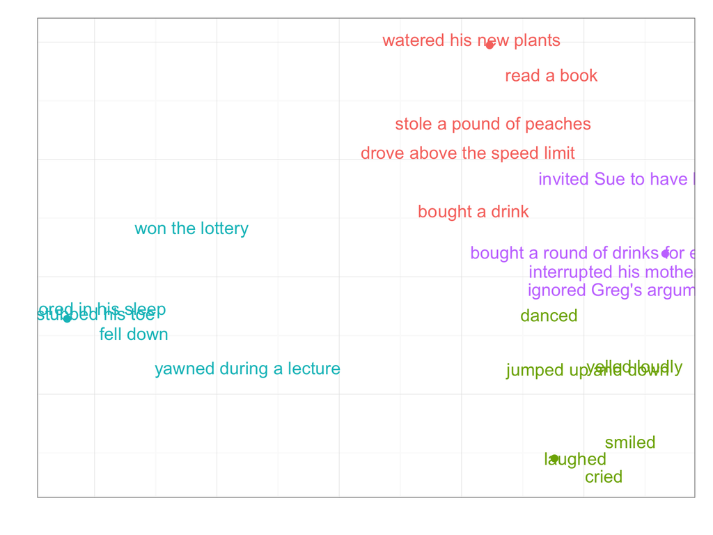

(The final mds plot is slightly different from the one in the paper; I think I generated it with a different seed last time?)